# Experiment 1: Airline Data Analysis

2023-09-06

Textbook section 4: Data Transformations (https://r4ds.hadley.nz/data-transform)

Here we use the provided data set from the US Bureau of Transportation Statistics of the 336,776 flights in NYC in 2013. This data set has already been cleaned and we will be working on transforming it.

```r
library(nycflights13)
library(tidyverse)
library(here)
library(janitor)
```

Now, we load the data into the variable df1.

```r
df1 = flights
```

We can view the data inside df1 with glimpse.

```r
glimpse(df1)
```

```
Rows: 336,776
Columns: 19
$ year           <int> 2013, 2013, 2013, 2013…
$ month          <int> 1, 1, 1, 1, 1, 1, 1, 1…
$ day            <int> 1, 1, 1, 1, 1, 1, 1, 1…
$ dep_time       <int> 517, 533, 542, 544, 55…
$ sched_dep_time <int> 515, 529, 540, 545, 60…
$ dep_delay      <dbl> 2, 4, 2, -1, -6, -4, -…
$ arr_time       <int> 830, 850, 923, 1004, 8…
$ sched_arr_time <int> 819, 830, 850, 1022, 8…
$ arr_delay      <dbl> 11, 20, 33, -18, -25, …
$ carrier        <chr> "UA", "UA", "AA", "B6"…
$ flight         <int> 1545, 1714, 1141, 725,…
$ tailnum        <chr> "N14228", "N24211", "N…
$ origin         <chr> "EWR", "LGA", "JFK", "…
$ dest           <chr> "IAH", "IAH", "MIA", "…
$ air_time       <dbl> 227, 227, 160, 183, 11…
$ distance       <dbl> 1400, 1416, 1089, 1576…
$ hour           <dbl> 5, 5, 5, 5, 6, 5, 6, 6…
$ minute         <dbl> 15, 29, 40, 45, 0, 58,…
$ time_hour      <dttm> 2013-01-01 05:00:00, …
```

09/06/23 Tasks: Task 1: df2 = flights from Miami in September

Task 2: df3 = flights in September going to Miami

Task 3: df4 = flights in January going to Miami

Task 4: df5 = flights in summer going to Chicago

```r
df2 = df1 |> filter(month == 9, origin == "MIA")
glimpse(df2)
```

```
Rows: 0
Columns: 19
$ year           <int>
$ month          <int>
$ day            <int>
$ dep_time       <int>
$ sched_dep_time <int>
$ dep_delay      <dbl>
$ arr_time       <int>
$ sched_arr_time <int>
$ arr_delay      <dbl>
$ carrier        <chr>
$ flight         <int>
$ tailnum        <chr>
$ origin         <chr>
$ dest           <chr>
$ air_time       <dbl>
$ distance       <dbl>
$ hour           <dbl>
$ minute         <dbl>
$ time_hour      <dttm>
```

```r
df3 = df1 |> filter(month == 9, dest == "MIA")
glimpse(df3)
```

```
Rows: 912
Columns: 19
$ year           <int> 2013, 2013, 2013, 2013…
$ month          <int> 9, 9, 9, 9, 9, 9, 9, 9…
$ day            <int> 1, 1, 1, 1, 1, 1, 1, 1…
$ dep_time       <int> 537, 552, 619, 705, 72…
$ sched_dep_time <int> 545, 600, 629, 710, 73…
$ dep_delay      <dbl> -8, -8, -10, -5, -8, -…
$ arr_time       <int> 849, 843, 900, 951, 10…
$ sched_arr_time <int> 855, 905, 929, 1025, 1…
$ arr_delay      <dbl> -6, -22, -29, -34, -18…
$ carrier        <chr> "AA", "AA", "AA", "AA"…
$ flight         <int> 701, 1895, 1921, 1165,…
$ tailnum        <chr> "N613AA", "N3KFAA", "N…
$ origin         <chr> "JFK", "LGA", "EWR", "…
$ dest           <chr> "MIA", "MIA", "MIA", "…
$ air_time       <dbl> 148, 149, 140, 143, 14…
$ distance       <dbl> 1089, 1096, 1085, 1089…
$ hour           <dbl> 5, 6, 6, 7, 7, 8, 9, 9…
$ minute         <dbl> 45, 0, 29, 10, 35, 29,…
$ time_hour      <dttm> 2013-09-01 05:00:00, …
```

```r
df4 = df1 |> filter(month == 1, dest == "MIA")
glimpse(df4)
```

```
Rows: 981
Columns: 19
$ year           <int> 2013, 2013, 2013, 2013…
$ month          <int> 1, 1, 1, 1, 1, 1, 1, 1…
$ day            <int> 1, 1, 1, 1, 1, 1, 1, 1…
$ dep_time       <int> 542, 606, 607, 623, 65…
$ sched_dep_time <int> 540, 610, 607, 610, 70…
$ dep_delay      <dbl> 2, -4, 0, 13, -5, -1, …
$ arr_time       <int> 923, 858, 858, 920, 10…
$ sched_arr_time <int> 850, 910, 915, 915, 10…
$ arr_delay      <dbl> 33, -12, -17, 5, -18, …
$ carrier        <chr> "AA", "AA", "UA", "AA"…
$ flight         <int> 1141, 1895, 1077, 1837…
$ tailnum        <chr> "N619AA", "N633AA", "N…
$ origin         <chr> "JFK", "EWR", "EWR", "…
$ dest           <chr> "MIA", "MIA", "MIA", "…
$ air_time       <dbl> 160, 152, 157, 153, 16…
$ distance       <dbl> 1089, 1085, 1085, 1096…
$ hour           <dbl> 5, 6, 6, 6, 7, 7, 7, 8…
$ minute         <dbl> 40, 10, 7, 10, 0, 0, 5…
$ time_hour      <dttm> 2013-01-01 05:00:00, …
```

```r
df5 = df1 |> filter(month %in% c(6, 7, 8), dest %in% c("ORD", "MDW"))
glimpse(df5)
```

```
Rows: 5,770
Columns: 19
$ year           <int> 2013, 2013, 2013, 2013…
$ month          <int> 6, 6, 6, 6, 6, 6, 6, 6…
$ day            <int> 1, 1, 1, 1, 1, 1, 1, 1…
$ dep_time       <int> 557, 619, 624, 629, 65…
$ sched_dep_time <int> 600, 630, 600, 630, 65…
$ dep_delay      <dbl> -3, -11, 24, -1, -1, 0…
$ arr_time       <int> 657, 727, 727, 743, 80…
$ sched_arr_time <int> 715, 805, 720, 800, 82…
$ arr_delay      <dbl> -18, -38, 7, -17, -15,…
$ carrier        <chr> "WN", "AA", "MQ", "B6"…
$ flight         <int> 2213, 303, 3768, 905, …
$ tailnum        <chr> "N959WN", "N4XPAA", "N…
$ origin         <chr> "EWR", "LGA", "EWR", "…
$ dest           <chr> "MDW", "ORD", "ORD", "…
$ air_time       <dbl> 101, 108, 104, 112, 10…
$ distance       <dbl> 711, 733, 719, 740, 73…
$ hour           <dbl> 6, 6, 6, 6, 6, 7, 7, 7…
$ minute         <dbl> 0, 30, 0, 30, 55, 0, 2…
$ time_hour      <dttm> 2013-06-01 06:00:00, …
```

09/08/23 Tasks: - Sometimes flight numbers are repeated. For flights to MIAMI in September, find the unique flight numbers. - Create a data frame df6 composed of flights to Miami with a flight number matching the smallest flight number from the set above. - Create a visualization (using ggplot) to show the DELAYS associated with this flight number.

```r
unique_df3 = df3 |> distinct(flight) |> arrange(flight)
glimpse(unique_df3)
```

```
Rows: 57
Columns: 1
$ flight <int> 83, 145, 172, 446, 476, 577, 6…
```

```r
df6 = df1 %>% filter (dest == "MIA", flight == 83)
glimpse(df6)
```

```
Rows: 146
Columns: 19
$ year           <int> 2013, 2013, 2013, 2013…
$ month          <int> 10, 10, 10, 10, 10, 10…
$ day            <int> 1, 2, 3, 4, 5, 6, 7, 8…
$ dep_time       <int> 1813, 1811, 1812, 1814…
$ sched_dep_time <int> 1814, 1814, 1814, 1814…
$ dep_delay      <dbl> -1, -3, -2, 0, 18, -2,…
$ arr_time       <int> 2047, 2100, 2056, 2049…
$ sched_arr_time <int> 2143, 2143, 2143, 2143…
$ arr_delay      <dbl> -56, -43, -47, -54, -2…
$ carrier        <chr> "DL", "DL", "DL", "DL"…
$ flight         <int> 83, 83, 83, 83, 83, 83…
$ tailnum        <chr> "N975DL", "N964DL", "N…
$ origin         <chr> "JFK", "JFK", "JFK", "…
$ dest           <chr> "MIA", "MIA", "MIA", "…
$ air_time       <dbl> 137, 144, 145, 134, 13…
$ distance       <dbl> 1089, 1089, 1089, 1089…
$ hour           <dbl> 18, 18, 18, 18, 18, 18…
$ minute         <dbl> 14, 14, 14, 14, 20, 14…
$ time_hour      <dttm> 2013-10-01 18:00:00, …
```

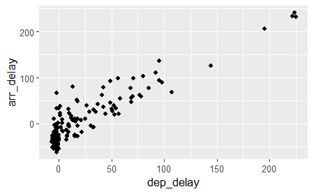

```r
df6 |> ggplot(aes(x = dep_delay, y = arr_delay)) +geom_point()
```

## Tasking at home: discover something more about delay

Questions: is flight timea ffected by delayed depature does the depatrure delay change across time of day is flight time pattern affected by time of year is depatrure delay affected by time of year.

```r
df1 |>
  filter(dest=="MIA")|>
  count(origin, sort= TRUE)
```

| origin | n |
| --- | --- |
| LGA | 5781 |
| JFK | 3314 |
| EWR | 2633 |

##is flight time affected by delayed departure

I want to examine wheather the flight time is impacted by delayed departure

I want to compare flight time to ‘planned’ flight time. So we create a new variable flt_delta= arr_delay-dep_delay

A flight that arrives 10 minutes late, if it departed on time, had a “Delta” of 10 minutes.

```r
df7=df1 |>
  filter(dest=="MIA", origin == "LGA")|>
  mutate(flt_delta= arr_delay-dep_delay)
```

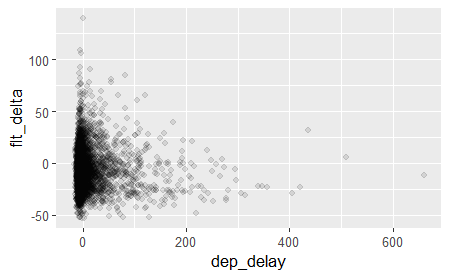

```r
df7|>
  ggplot(aes(x=dep_delay, y=flt_delta))+geom_point(alpha=.1)
```

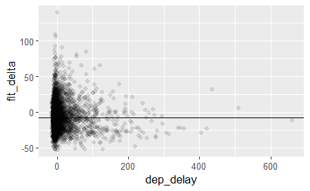

```r
df7 |>  ggplot(aes(x=dep_delay, y=flt_delta))+geom_point(alpha=.1) + geom_hline(aes(yintercept=mean(flt_delta,na.rm=TRUE)))
```

```r
NA
```

## is the departure delay affected by time of year

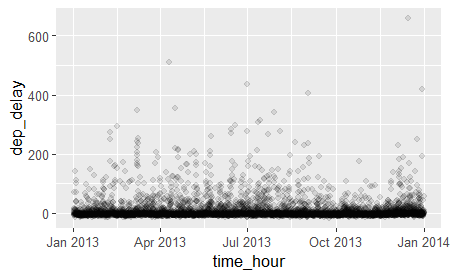

```r
df7 |>
  ggplot(aes(x=time_hour,y=dep_delay)) + geom_point(alpha=.1)
```

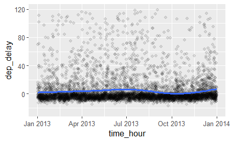

```r
df7 |>
  ggplot(aes(x=time_hour,y=dep_delay)) + geom_point(alpha = .1) + stat_smooth()+
  ylim(-25,120)
```

*** why are delays bigger in december than january — probably not weather***

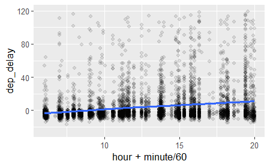

```r
df7 |>
  ggplot(aes(x=hour+minute/60, y=dep_delay))+geom_point(alpha=.1)+stat_smooth()+
  ylim(-25,120)
```

Observation *departure delay increase across the flight day

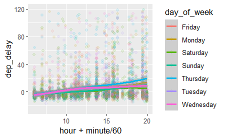

```r
df7|>
  mutate(day_of_week = weekdays(time_hour)) |>
  ggplot(aes(x=hour+minute/60,y=dep_delay,color=day_of_week)) + geom_point(alpha=.1) + stat_smooth()+ ylim(-25,120)
```

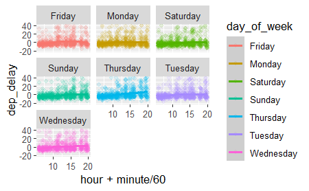

```r
df7|>
  mutate(day_of_week=weekdays(time_hour)) |> ggplot(aes(x=hour+minute/60,y=dep_delay,color=day_of_week))+geom_point(alpha=.1)+stat_smooth()+ylim(-20,40)+facet_wrap(~day_of_week)
```